# Cluster Analysis

Clustering Collegiate Women’s Basketball Teams

Jade Gosar

2023-11-03

### Data Source

The data used for this analysis came from Sports Reference (https://www.sports-reference.com/cbb/) which provides game metrics and advanced statistics for multiple collegiate and professional sports teams and leagues. The following cluster models and analysis are based on collegiate womens basketball teams that were in the PAC12 or ended the season ranked in the AP top 25.

### Data Cleaning and Manipulation

After getting the Sport Reference stats together for all teams in the top 25 and the PAC 12, I added a column to represent the net ranking which let a strength of schedule metric be incorporated into the cluster analysis that is used by the NCAA to rank teams beyond simply wins and losses. After looking at how the teams compare across the important metrics in the dataset, the decision was made to remove cal and asu as they were not able to be easily grouped with the other teams due to their performance being two of the worst in the PAC12 and having by far the lowest net rankings across the teams.

```r
# Add net rankings
sr_stats_teams$NET_Ranking <- ifelse(sr_stats_teams$Team_Name == "arizona", 27, ifelse(sr_stats_teams$Team_Name == "asu", 113, ifelse(sr_stats_teams$Team_Name == "cal", 82, ifelse(sr_stats_teams$Team_Name == "connecticut", 3, ifelse(sr_stats_teams$Team_Name == "cu", 20, ifelse(sr_stats_teams$Team_Name == "duke", 10, ifelse(sr_stats_teams$Team_Name == "gonzaga", 49, ifelse(sr_stats_teams$Team_Name == "indiana", 5, ifelse(sr_stats_teams$Team_Name == "iowa", 6, ifelse(sr_stats_teams$Team_Name == "lsu", 2, ifelse(sr_stats_teams$Team_Name == "maryland", 11, ifelse(sr_stats_teams$Team_Name == "michigan", 25, ifelse(sr_stats_teams$Team_Name == "middle_tennessee", 33, ifelse(sr_stats_teams$Team_Name == "nevada_LV", 52, ifelse(sr_stats_teams$Team_Name == "notre_dame", 9, ifelse(sr_stats_teams$Team_Name == "ohio_state", 16, ifelse(sr_stats_teams$Team_Name == "oklahoma", 38, ifelse(sr_stats_teams$Team_Name == "oregon", 21, ifelse(sr_stats_teams$Team_Name == "oregon_state", 55, ifelse(sr_stats_teams$Team_Name == "south_carolina", 1, ifelse(sr_stats_teams$Team_Name == "stanford", 4, ifelse(sr_stats_teams$Team_Name == "tennessee", 13, ifelse(sr_stats_teams$Team_Name == "texas", 12, ifelse(sr_stats_teams$Team_Name == "ucla", 22, ifelse(sr_stats_teams$Team_Name == "unc", 24, ifelse(sr_stats_teams$Team_Name == "usc", 34, ifelse(sr_stats_teams$Team_Name == "utah", 8, ifelse(sr_stats_teams$Team_Name == "villanova", 14, ifelse(sr_stats_teams$Team_Name == "virginia_tech", 7, ifelse(sr_stats_teams$Team_Name == "washington", 63, ifelse(sr_stats_teams$Team_Name == "wsu", 35, ifelse(sr_stats_teams$Team_Name == "asu", 113, NA))))))))))))))))))))))))))))))))

# Remove outliers
sr_top_teams <- sr_stats_teams %>%
  filter(Team_Name != "asu" & Team_Name != "cal")
```

### Initial Data Visualization

The first step in the analysis was to create a dataframe that contains the season averages of the important metrics for each team.

```r
# Make Team name a factor variable
sr_top_teams$Team_Name <- as.factor(sr_top_teams$Team_Name)

# Calculate team averages for all SR stats
sr_team_averages <- sr_top_teams %>%
  group_by(Team_Name) %>%
  summarize(Avg_Team_Points = mean(`Team Points`),
            Avg_Opponents_Points = mean(`Opponents Points`),
            Avg_3PAr = mean(`3PAr`),
            Avg_TS_Perc = mean(`TS%`),
            Avg_TRB_Perc = mean(`TRB%`),
            Avg_AST_Perc = mean(`AST%`),
            Avg_STL_Perc = mean(`STL%`),
            Avg_BLK = mean(`BLK`),
            Avg_Off_EFG_Perc = mean(`Offensive eFG%`),
            Avg_Opponent_EFG_Perc = mean(`Defensive eFG%`),
            Avg_Off_TOV_Perc = mean(`Offensive TOV%`),
            Avg_ORB_Perc = mean(`Offensive ORB%`),
            Avg_Opponent_TOV_Perc = mean(`Defensive TOV%`),
            Avg_DRB_Perc = mean(`Defensive DRB%`),
            Avg_Opponent_FT_FGA = mean(`Defensive FT/FGA`),
            Avg_FT_FGA = mean(`Defensive FT/FGA`))

sr_team_averages
```

```
## # A tibble: 29 × 17
##    Team_Name   Avg_Team_Points Avg_Opponents_Points Avg_3PAr Avg_TS_Perc
##    <fct>                 <dbl>                <dbl>    <dbl>       <dbl>
##  1 arizona                74.1                 65.1    0.255       0.508
##  2 connecticut            75.9                 58.8    0.290       0.573
##  3 cu                     69.2                 59.3    0.284       0.515
##  4 duke                   63.6                 51.0    0.266       0.488
##  5 gonzaga                71.6                 59.9    0.331       0.550
##  6 indiana                80.9                 62.1    0.325       0.591
##  7 iowa                   87.3                 71.8    0.398       0.618
##  8 lsu                    82.3                 57.9    0.229       0.537
##  9 maryland               79.1                 68.7    0.289       0.541
## 10 michigan               73.5                 63.4    0.304       0.555
## # ℹ 19 more rows
## # ℹ 12 more variables: Avg_TRB_Perc <dbl>, Avg_AST_Perc <dbl>,
## #   Avg_STL_Perc <dbl>, Avg_BLK <dbl>, Avg_Off_EFG_Perc <dbl>,
## #   Avg_Opponent_EFG_Perc <dbl>, Avg_Off_TOV_Perc <dbl>, Avg_ORB_Perc <dbl>,
## #   Avg_Opponent_TOV_Perc <dbl>, Avg_DRB_Perc <dbl>, Avg_Opponent_FT_FGA <dbl>,
## #   Avg_FT_FGA <dbl>
```

The below visualization plots the teams used in the cluster analysis comparing them across only two metrics. Average lines across the data frame are shown as well to split the teams into four quadrants: teams with an above average eFG% and opponent eFG% (very efficient offenses with below average defense), teams with an above average eFG% and below average opponent eFG% (good offense, great defense), teams with below average eFG% and eFG% allowed (good defense, below average offense), and teams with a below average eFG% but above average opponent eFG% allowed (these teams perform the worst along both metrics).

```
## Inverted geom defaults of fill and color/colour.
## To change them back, use invert_geom_defaults().
```

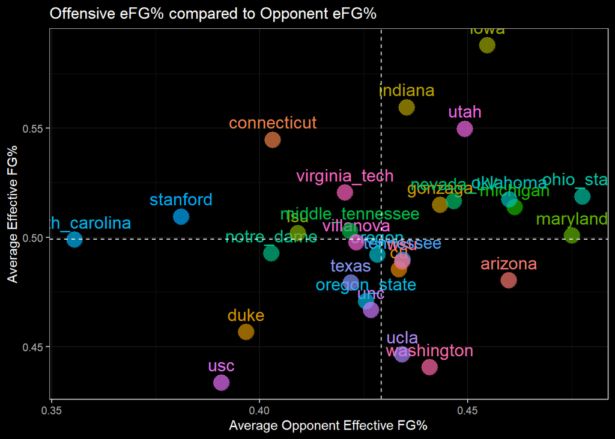

```r
ggplot(sr_team_averages, # Set dataset for aesthetics
              aes(y = `Avg_Off_EFG_Perc`, x = `Avg_Opponent_EFG_Perc`, color = Team_Name)) +
  geom_text(aes(label = Team_Name), size = 5, hjust = 0.5, vjust = -0.9) + # Add team names as labels next to points
  geom_point(size = 6, alpha = 0.7) + # Use geom point for scatter plot
  theme(axis.line = element_line(colour = "black"),
        axis.text.x = element_text(angle = 90),
        panel.grid.major = element_blank(),
        panel.grid.minor = element_blank(),
        panel.border = element_blank(),
        panel.background = element_blank(),
        plot.title = element_text(size = 22),
        axis.title.y = element_text(size = 20),  # Adjust y-axis label size
        axis.title.x = element_text(size = 20),  # Adjust x-axis label size
        axis.text = element_text(size = 14),  # Adjust axis tick label size
        legend.position = "none") + # Remove grid
  labs(y = "Average Effective FG%", x = "Average Opponent Effective FG%", color = "Team", # Set labels
     title = "Offensive eFG% compared to Opponent eFG%") +
  dark_theme_bw() +
  geom_vline(aes(xintercept = mean(`Avg_Opponent_EFG_Perc`)), linetype = "dashed", color = "white") +
  geom_hline(aes(yintercept = mean(`Avg_Off_EFG_Perc`)), linetype = "dashed", color = "white") +
  theme(legend.position = "none")
```

### K-means Cluster Analysis

The first clustering approach was to use averages for almost all of the metrics. This cluster analysis will be more complex and includes variables such as pace, 3 point attempt rate, and blocks that were not deemed significant in the logistic regression model on these stats using game outcome as the target variable. The approach will be to compare this analysis to a second model on just the significant predictors to see how much they differ and which captures the data more accurately.

```r
# Create df with averages of almost all metrics
df_for_cluster_analysis2 <- sr_top_teams %>%
  group_by(Team_Name) %>%
  summarize(Number_Of_Wins = sum(`W/L` == "W"),
            Number_Of_Losses = sum(`W/L` == "L"),
            NET_rank = mean(NET_Ranking),
            Avg_Pace = mean(`Pace`),
            Avg_3PAr = mean(`3PAr`),
            Avg_AST_Perc = mean(`AST%`),
            Avg_STL_Perc = mean(`STL%`),
            Avg_BLK = mean(`BLK`),
            Avg_Off_EFG_Perc = mean(`Offensive eFG%`),
            Avg_Opponent_EFG_Perc = mean(`Defensive eFG%`),
            Avg_Off_TOV_Perc = mean(`Offensive TOV%`),
            Avg_ORB_Perc = mean(`Offensive ORB%`),
            Avg_FT_Per_FGA = mean(`Offensive FT/FGA`),
            Avg_DRB_Perc = mean(`Defensive DRB%`),
            Avg_Opponent_FT_FGA = mean(`Defensive FT/FGA`))

# Make the df into a data frame
df_for_cluster_analysis2 <- as.data.frame(df_for_cluster_analysis2)

# Scale the variables to standardize numeric inputs
cluster_df_scaled2 <- scale(df_for_cluster_analysis2[-1])

# Add teams back into data frame
cluster_1_w_names <- cbind.data.frame(df_for_cluster_analysis2$Team_Name, cluster_df_scaled2)

# Fix name of team column
names(cluster_1_w_names)[1] <- "teams"
```

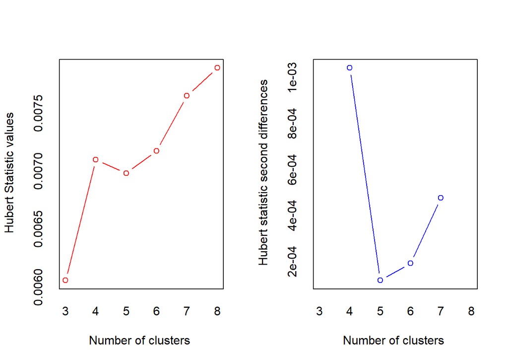

```
## *** : The Hubert index is a graphical method of determining the number of clusters.
##                 In the plot of Hubert index, we seek a significant knee that corresponds to a
##                 significant increase of the value of the measure i.e the significant peak in Hubert
##                 index second differences plot.
##
```

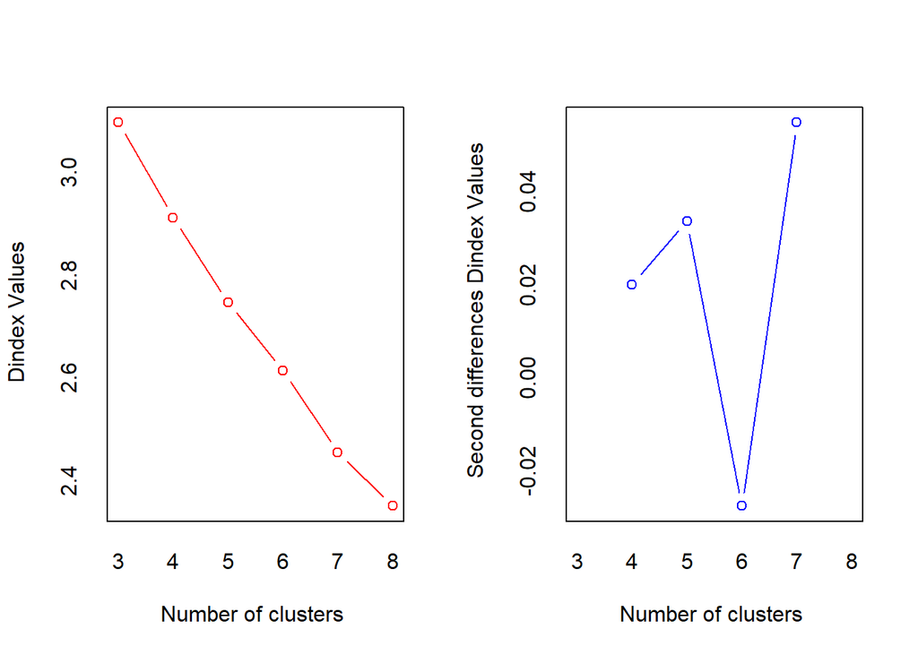

```
## *** : The D index is a graphical method of determining the number of clusters.
##                 In the plot of D index, we seek a significant knee (the significant peak in Dindex
##                 second differences plot) that corresponds to a significant increase of the value of
##                 the measure.
##
## * Among all indices:
## * 9 proposed 3 as the best number of clusters
## * 7 proposed 4 as the best number of clusters
## * 1 proposed 6 as the best number of clusters
## * 2 proposed 7 as the best number of clusters
## * 3 proposed 8 as the best number of clusters
##
##                    ***** Conclusion *****
##
## * According to the majority rule, the best number of clusters is  3
##
##
```

```r
set.seed(5493)

# Select only numeric columns to run cluster analysis on
num_cols <- cluster_1_w_names %>%
  select_if(is.numeric)

# Determine the optimal number of clusters using euclidean distance
res <- NbClust(num_cols, distance = "euclidean", min.nc=3, max.nc=8,
method = "ward.D2", index = "all")
```

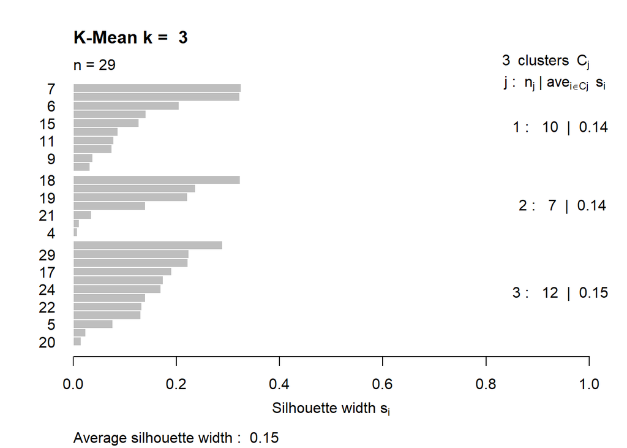

```r
set.seed(76964057) #Set seed for reproducibility

clust = 3 #Create 3 clusters

dis = dist(cluster_1_w_names[-1], method="euclidean") # for K means silhouette

k_3 <- kmeans(cluster_1_w_names[-1], centers=clust, nstart = 25)
#nstart=25 sets 25 initial random centroids and then selects the best one

#the following code runs K Medoid clustering
k_m <- pam(cluster_1_w_names[-1], clust)

sil = silhouette (k_3$cluster, dis) # for silhouette plots
plot(sil,main=paste("K-Mean k = ",clust))
```

```r
# Print centers to show how clusters relate to one another
print(k_3$centers)
```

```
##   Number_Of_Wins Number_Of_Losses    NET_rank    Avg_Pace   Avg_3PAr
## 1      0.3610985       -0.3840075 -0.07218644  0.66211193  0.7617770
## 2      0.7696391       -0.6566150 -0.89811701 -0.07302798 -1.1067030
## 3     -0.7498716        0.7030317  0.58405696 -0.50916029  0.0107626
##   Avg_AST_Perc Avg_STL_Perc    Avg_BLK Avg_Off_EFG_Perc Avg_Opponent_EFG_Perc
## 1    0.3496334  -0.13195925 -0.5978662       0.85202485            0.75759342
## 2   -0.2236313   0.02975343  1.2170304      -0.04579428           -1.20833178
## 3   -0.1609096   0.09260987 -0.2117126      -0.68330738            0.07353236
##   Avg_Off_TOV_Perc Avg_ORB_Perc Avg_FT_Per_FGA Avg_DRB_Perc Avg_Opponent_FT_FGA
## 1      -0.12651069  -0.69931494      0.7449651   0.04283293          0.21806924
## 2       0.26097422   1.12642249      0.1526624   0.86991880         -0.14941711
## 3      -0.04680938  -0.07431734     -0.7098573  -0.54314674         -0.09456438
```

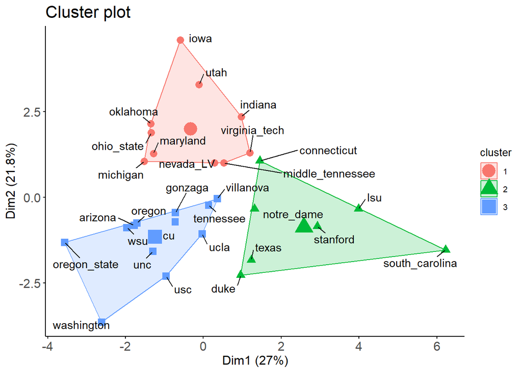

```r
# Extract team names to be able to show on plot
team_names <- df_for_cluster_analysis2$Team_Name

# Create a new data frame with team names
cluster_df_with_names <- data.frame(Team_Name = team_names, cluster_df_scaled2)

# Create cluster plot
p <- fviz_cluster(k_3, data = cluster_df_scaled2, repel = TRUE)

# Plot cluster visualization
p <- fviz_cluster(k_3, data = cluster_df_scaled2, geom = "point", pointsize = 3,
                  repel = TRUE, ggtheme = theme_classic(base_size = 10)) +
       theme(axis.title = element_text(size = 12),
             axis.text = element_text(size = 12),
             plot.title = element_text(size = 16))

# Add text labels for team names
p + geom_text_repel(aes(label = df_for_cluster_analysis2$Team_Name), color = "black", box.padding = 0.5)
```

```r
# Extract clusters
clusters_1 <- k_3$cluster

# Extract centers
centers_1 <- k_3$centers

# Check samples per cluster
summary(as.factor(clusters_1))
```

```
##  1  2  3
## 10  7 12
```

```r
# Check teams in cluster 1
cat("Cluster 1 teams:\n")
```

```
## Cluster 1 teams:
```

```r
cluster_1_w_names$teams[clusters_1 == 1]
```

```
##  [1] indiana          iowa             maryland         michigan
##  [5] middle_tennessee nevada_LV        ohio_state       oklahoma
##  [9] utah             virginia_tech
## 29 Levels: arizona connecticut cu duke gonzaga indiana iowa lsu ... wsu
```

```r
# Check teams in cluster 2
cat("Cluster 2 teams:\n")
```

```
## Cluster 2 teams:
```

```r
cluster_1_w_names$teams[clusters_1 == 2]
```

```
## [1] connecticut    duke           lsu            notre_dame     south_carolina
## [6] stanford       texas
## 29 Levels: arizona connecticut cu duke gonzaga indiana iowa lsu ... wsu
```

```r
# Check teams in cluster 3
cat("Cluster 3 teams:\n")
```

```
## Cluster 3 teams:
```

```r
cluster_1_w_names$teams[clusters_1 == 3]
```

```
##  [1] arizona      cu           gonzaga      oregon       oregon_state
##  [6] tennessee    ucla         unc          usc          villanova
## [11] washington   wsu
## 29 Levels: arizona connecticut cu duke gonzaga indiana iowa lsu ... wsu
```

```r
# Create vector of clusters
cluster <- c(1:3)

# Extract centers
center_df <- data.frame(cluster, centers_1)

# Reshape the data
center_reshape <- gather(center_df, features, values, Number_Of_Wins:Avg_Opponent_FT_FGA)

# View first 20 rows
head(center_reshape, 20)
```

```
##    cluster         features      values
## 1        1   Number_Of_Wins  0.36109853
## 2        2   Number_Of_Wins  0.76963914
## 3        3   Number_Of_Wins -0.74987161
## 4        1 Number_Of_Losses -0.38400753
## 5        2 Number_Of_Losses -0.65661499
## 6        3 Number_Of_Losses  0.70303168
## 7        1         NET_rank -0.07218644
## 8        2         NET_rank -0.89811701
## 9        3         NET_rank  0.58405696
## 10       1         Avg_Pace  0.66211193
## 11       2         Avg_Pace -0.07302798
## 12       3         Avg_Pace -0.50916029
## 13       1         Avg_3PAr  0.76177695
## 14       2         Avg_3PAr -1.10670295
## 15       3         Avg_3PAr  0.01076260
## 16       1     Avg_AST_Perc  0.34963341
## 17       2     Avg_AST_Perc -0.22363126
## 18       3     Avg_AST_Perc -0.16090961
## 19       1     Avg_STL_Perc -0.13195925
## 20       2     Avg_STL_Perc  0.02975343
```

```r
# Create heat plot
g_heat_1 <- ggplot(data = center_reshape,
                   aes(x = features, y = cluster, fill = values)) +
  scale_y_continuous(breaks = seq(1, 3, by = 1)) +
  geom_tile() +
  coord_equal() +
  theme_set(theme_bw(base_size = 20)) +
  scale_fill_gradient2(low = "blue",
                       mid = "white",
                       high = "red",
                       midpoint = 0,
                       space = "Lab",
                       na.value = "grey",
                       guide = "colourbar",
                       aesthetics = "fill") +
  coord_flip() +
  theme(axis.title = element_text(size = 16),
        axis.text = element_text(size = 13, color = "black"),
        legend.title = element_text(size = 13),
        legend.text = element_text(size = 12))
```

```
## replace the existing one.
```

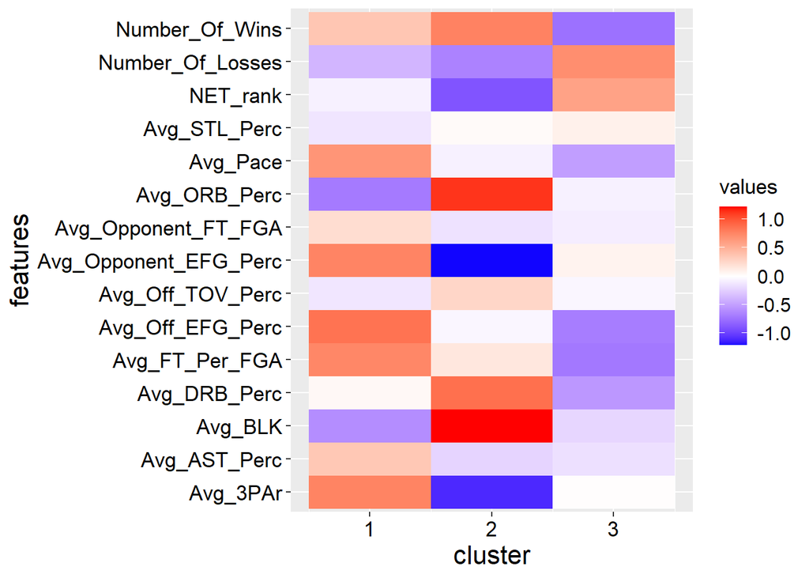

```r
g_heat_1
```

From this analysis we can see how teams in one cluster compare to teams from different clusters across all metrics shown in the visualization above. If we were interested in finding how the first cluster is similar and different to other clusters, we would see that cluster 1 tends to have a slightly lower steal percentage and plays at a faster pace. This group of teams has the lowest offensive rebound percentage by quite a large margin, the highest eFG% allowed by opponents, and performs very well in offensive metrics such as eFG%, assist percentage, and shoots a higher rate of free throws per field goal attempt. Lastly, cluster 1 teams have an average defensive rebound percentage and has a much higher three point attempt rate compared to cluster 2 and 3. Cluster 2 contains many high performing teams, such as LSU, South Carolina, and Stanford, that tend to rely more heavily on defense rather than offense to win games. They have the lowest opponent eFG% by a long shot, shoot a much lower number of threes, and rely heavily on both offensive and defensive rebounding. They also tend to turn the ball over more than clusters 1 and 3, get a much higher number of blocks, and perform about average (fall between the best and worst cluster) across all other metrics. From this model it is clear that teams in cluster 1 rely much more heavily on offensive metrics to win games in which they shoot more 3s and play at a faster pace while teams from cluster 2 tend to rely on playing great defense and getting boards on both ends of the court.

I followed a very similar process to the first cluster analysis below but only used variables that were deemed significant by our logisitic regression on game outcome to compare if creating a cluster model with just these variables better captures the groupings in the data.

```r
# Create df with averages of significant metrics from logisitic regression
df_for_cluster_analysis_imp <- sr_top_teams %>%
  group_by(Team_Name) %>%
  summarize(Number_Of_Wins = sum(`W/L` == "W"),
            NET_rank = mean(NET_Ranking),
            Avg_STL_Perc = mean(`STL%`),
            Avg_Off_EFG_Perc = mean(`Offensive eFG%`),
            Avg_Opponent_EFG_Perc = mean(`Defensive eFG%`),
            Avg_Off_TOV_Perc = mean(`Offensive TOV%`),
            Avg_ORB_Perc = mean(`Offensive ORB%`),
            Avg_FT_Per_FGA = mean(`Offensive FT/FGA`),
            Avg_DRB_Perc = mean(`Defensive DRB%`),
            Avg_Opponent_FT_FGA = mean(`Defensive FT/FGA`))

# Make the df into a data frame type
df_for_cluster_analysis_imp <- as.data.frame(df_for_cluster_analysis_imp)

# Scale the variables to standardize numeric inputs
cluster_df_scaled_imp <- scale(df_for_cluster_analysis_imp[-1])

# Add teams back into data frame
cluster_2_w_names <- cbind.data.frame(df_for_cluster_analysis_imp$Team_Name, cluster_df_scaled_imp)

# Fix name of team column
names(cluster_2_w_names)[1] <- "teams"
```

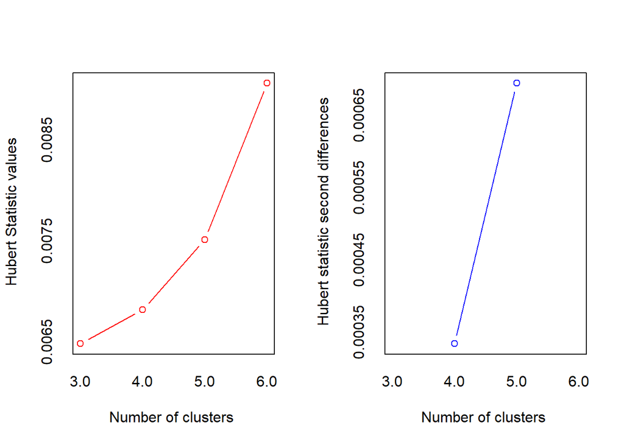

```
## *** : The Hubert index is a graphical method of determining the number of clusters.
##                 In the plot of Hubert index, we seek a significant knee that corresponds to a
##                 significant increase of the value of the measure i.e the significant peak in Hubert
##                 index second differences plot.
##
```

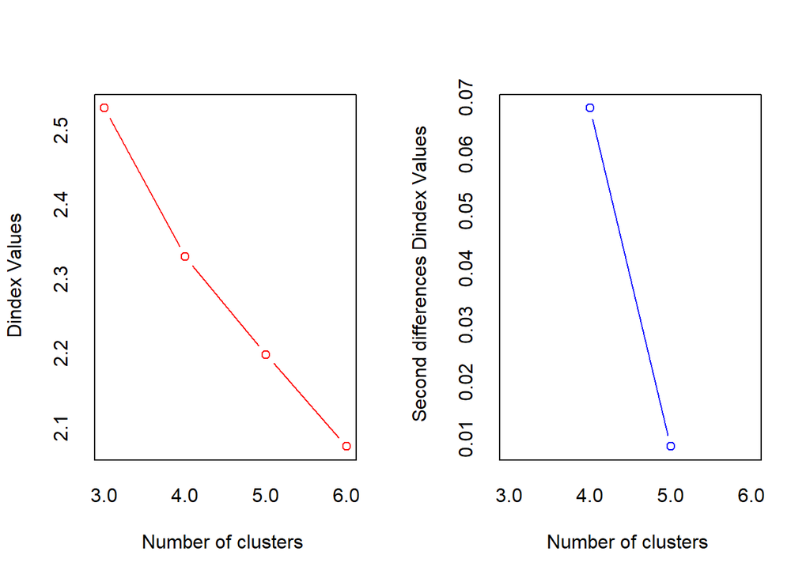

```
## *** : The D index is a graphical method of determining the number of clusters.
##                 In the plot of D index, we seek a significant knee (the significant peak in Dindex
##                 second differences plot) that corresponds to a significant increase of the value of
##                 the measure.
##
## * Among all indices:
## * 6 proposed 3 as the best number of clusters
## * 7 proposed 4 as the best number of clusters
## * 4 proposed 5 as the best number of clusters
## * 5 proposed 6 as the best number of clusters
##
##                    ***** Conclusion *****
##
## * According to the majority rule, the best number of clusters is  4
##
##
```

```r
set.seed(6493)

# Select only numeric columns from cluster df to run analysis on
num_cols_imp <- cluster_2_w_names %>%
  select_if(is.numeric)

# Determine the optimal number of clusters using euclidean distance
res<-NbClust(num_cols_imp, distance = "euclidean", min.nc=3, max.nc=6,
method = "ward.D2", index = "all")
```

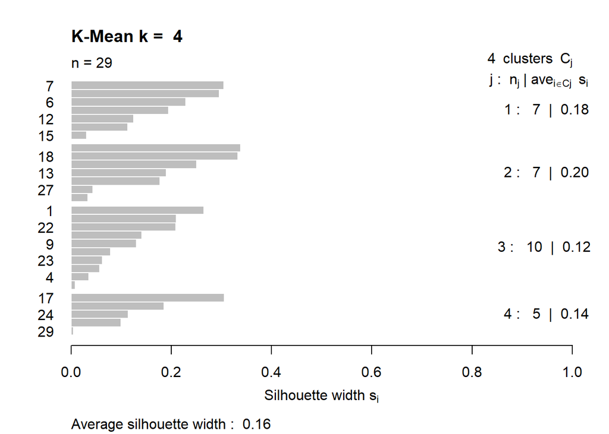

```r
set.seed(769657) #Set seed for reproducibility

clust = 4 #Create 4 clusters

dis2 = dist(cluster_2_w_names[-1], method="euclidean") # for K means silhouette

k_4_imp <- kmeans(cluster_2_w_names[-1], centers=clust, nstart = 25)
#nstart=25 sets 25 initial random centroids and then selects the best one

#the following code runs K Medoid clustering
k_m <- pam(cluster_2_w_names[-1], clust)

sil = silhouette (k_4_imp$cluster, dis2) # for silhouette plots
plot(sil,main=paste("K-Mean k = ",clust))
```

```r
# Print centers to show how clusters relate to one another
print(k_4_imp$centers)
```

```
##   Number_Of_Wins   NET_rank Avg_STL_Perc Avg_Off_EFG_Perc Avg_Opponent_EFG_Perc
## 1     0.22892362  0.1456869   -0.4129446        1.0431867             0.6411652
## 2     0.88979815 -0.9146853   -0.5633803        0.2596024            -1.0211335
## 3    -0.01740234 -0.0489908    0.8953531       -0.4205184             0.3612674
## 4    -1.53140580  1.1745794   -0.4238513       -0.9828679            -0.1905791
##   Avg_Off_TOV_Perc Avg_ORB_Perc Avg_FT_Per_FGA Avg_DRB_Perc Avg_Opponent_FT_FGA
## 1      -0.02016583   -0.6627026      1.0062432    0.3244260           0.4183034
## 2       0.03986105    1.0487006      0.4501297    0.9752620          -0.5362458
## 3      -0.24802176   -0.1385211     -0.5732215   -0.5584577           0.5862318
## 4       0.46847021   -0.2633551     -0.8924789   -0.7026478          -1.0073443
```

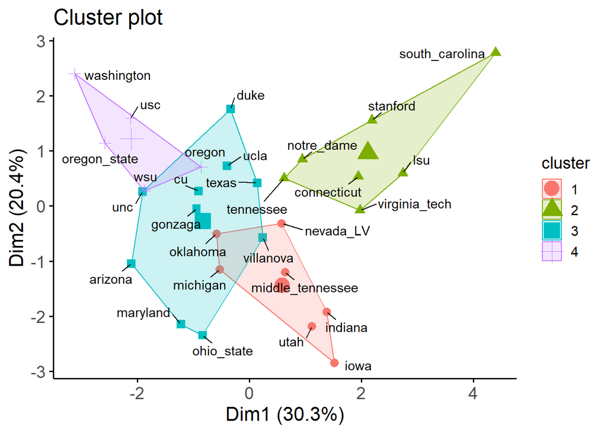

```r
# Extract team names to be able to show on plot
team_names <- df_for_cluster_analysis_imp$Team_Name

# Create a new data frame with team names
cluster_df_with_names <- data.frame(Team_Name = team_names, cluster_df_scaled_imp)

# Create cluster plot
p <- fviz_cluster(k_4_imp, data = cluster_df_scaled_imp, geom = "point", pointsize = 3,
                  repel = TRUE, ggtheme = theme_classic(base_size = 14)) +
       theme(axis.title = element_text(size = 16),
             axis.text = element_text(size = 14),
             plot.title = element_text(size = 18))


# Add text labels for team names
p + geom_text_repel(aes(label = df_for_cluster_analysis_imp$Team_Name), color = "black", box.padding = 0.5)
```

```r
# Extract clusters
clusters_2 <- k_4_imp$cluster

# Extract centers
centers_2 <- k_4_imp$centers

# Check samples per cluster
summary(as.factor(clusters_2))
```

```
##  1  2  3  4
##  7  7 10  5
```

```r
# Check teams in cluster 1
cat("Cluster 1 teams:\n")
```

```
## Cluster 1 teams:
```

```r
cluster_2_w_names$teams[clusters_2 == 1]
```

```
## [1] indiana          iowa             michigan         middle_tennessee
## [5] nevada_LV        oklahoma         utah
## 29 Levels: arizona connecticut cu duke gonzaga indiana iowa lsu ... wsu
```

```r
# Check teams in cluster 2
cat("Cluster 2 teams:\n")
```

```
## Cluster 2 teams:
```

```r
cluster_2_w_names$teams[clusters_2 == 2]
```

```
## [1] connecticut    lsu            notre_dame     south_carolina stanford
## [6] tennessee      virginia_tech
## 29 Levels: arizona connecticut cu duke gonzaga indiana iowa lsu ... wsu
```

```r
# Check teams in cluster 3
cat("Cluster 3 teams:\n")
```

```
## Cluster 3 teams:
```

```r
cluster_2_w_names$teams[clusters_2 == 3]
```

```
##  [1] arizona    cu         duke       gonzaga    maryland   ohio_state
##  [7] texas      ucla       unc        villanova
## 29 Levels: arizona connecticut cu duke gonzaga indiana iowa lsu ... wsu
```

```r
# Check teams in cluster 4
cat("Cluster 4 teams:\n")
```

```
## Cluster 4 teams:
```

```r
cluster_2_w_names$teams[clusters_2 == 4]
```

```
## [1] oregon       oregon_state usc          washington   wsu
## 29 Levels: arizona connecticut cu duke gonzaga indiana iowa lsu ... wsu
```

```r
# Create vector of clusters
cluster2 <- c(1:4)

# Extract centers
center_df2 <- data.frame(cluster2, centers_2)

# Reshape the data
center_reshape2 <- gather(center_df2, features, values, Number_Of_Wins:Avg_Opponent_FT_FGA)
```

```r
# Create heat map plot
g_heat_2 <- ggplot(data = center_reshape2,
                   aes(x = features, y = cluster2, fill = values)) +
  scale_y_continuous(breaks = seq(1, 4, by = 1)) +
  geom_tile() +
  coord_equal() +
  theme_set(theme_bw(base_size = 20)) +
  scale_fill_gradient2(low = "blue",
                       mid = "white",
                       high = "red",
                       midpoint = 0,
                       space = "Lab",
                       na.value = "grey",
                       guide = "colourbar",
                       aesthetics = "fill") +
  coord_flip() +
  theme(axis.title = element_text(size = 16),
        axis.text = element_text(size = 13, color = "black"),
        legend.title = element_text(size = 13),
        legend.text = element_text(size = 12))
```

```
## replace the existing one.
```

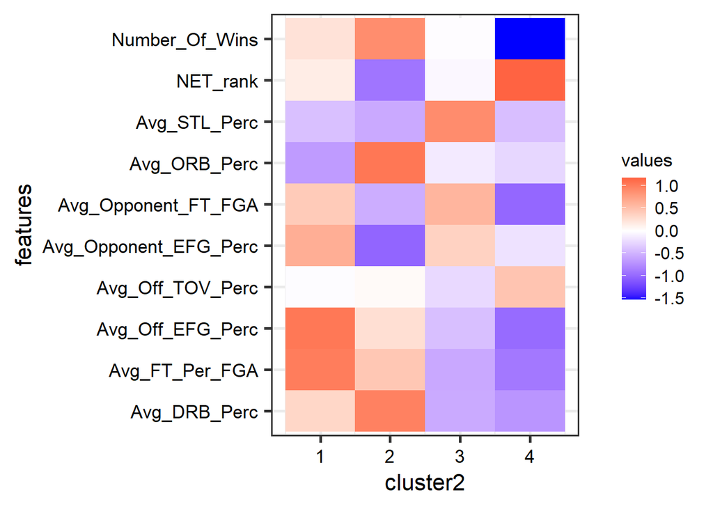

```r
g_heat_2
```

### Hierarchical clustering

The next analysis I ran was a hierarchical clustering model. This model is meant to show which teams across the entire data set are most similar and dissimilar from each team and can be used to validate that the clustering analysis is correctly grouping teams together. There are three different types of linkages that you can specify when performing hierarchical clustering which will be bench marked against each other to see which is the most accurate. You can kind of read the diagrams as the lower the branch between the two points, the more similar they are so if the original branch between them is very high up it means they are very dissimilar to each other.

```r
# Add row numbers as a new column and display them next to Team_Name
df_with_row_numbers <- df_for_cluster_analysis2 %>%
  rownames_to_column(var = "Row_Num")

# Print the updated data frame
print(df_with_row_numbers[,c(1:2)])
```

```
##    Row_Num        Team_Name
## 1        1          arizona
## 2        2      connecticut
## 3        3               cu
## 4        4             duke
## 5        5          gonzaga
## 6        6          indiana
## 7        7             iowa
## 8        8              lsu
## 9        9         maryland
## 10      10         michigan
## 11      11 middle_tennessee
## 12      12        nevada_LV
## 13      13       notre_dame
## 14      14       ohio_state
## 15      15         oklahoma
## 16      16           oregon
## 17      17     oregon_state
## 18      18   south_carolina
## 19      19         stanford
## 20      20        tennessee
## 21      21            texas
## 22      22             ucla
## 23      23              unc
## 24      24              usc
## 25      25             utah
## 26      26        villanova
## 27      27    virginia_tech
## 28      28       washington
## 29      29              wsu
```

The model that performed the best was the average linkage, shown below. For an example of how to use this model to find teams that are most similar and different, lets look at team 25. In this cluster model the teams that are the most similar to team 25 are Iowa (7), Indiana (6), and Oklahoma (15) and the teams that are the least similar are LSU (8), South Carolina (18), and Stanford (19). This model helps to confirm what we found in the original cluster model which is that these two groups of teams have very different styles of play.

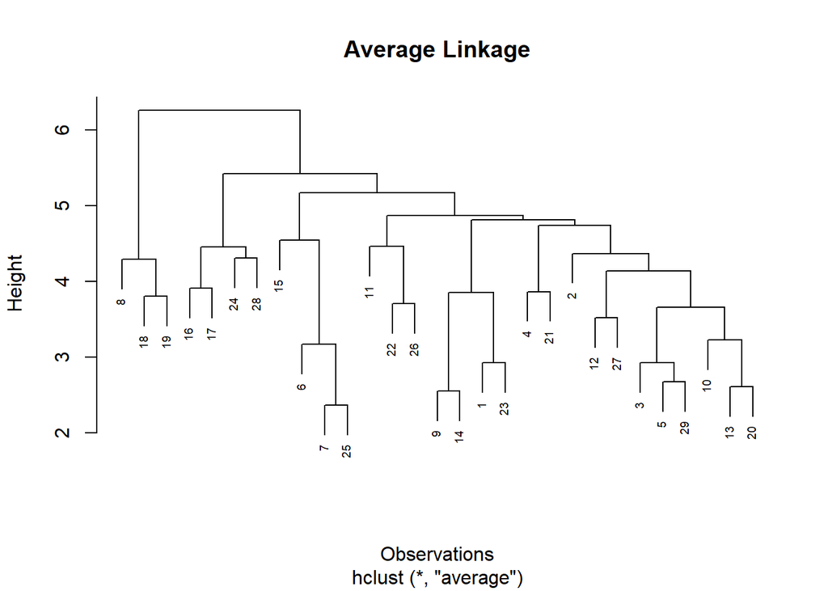

```r
# Create data for hierarchical clustering
d <- dist(cluster_1_w_names[,-c(1, 3)], method = "euclidean")

# Create hierarchical clustering model using average linkage
fit.a <- hclust(d, method="average")
plot(fit.a, main = "Average Linkage", xlab = "Observations", ylab = "Height", cex = .6)
```

The model below shows the same results as above but performs slightly worse at representing the similarity between the teams.

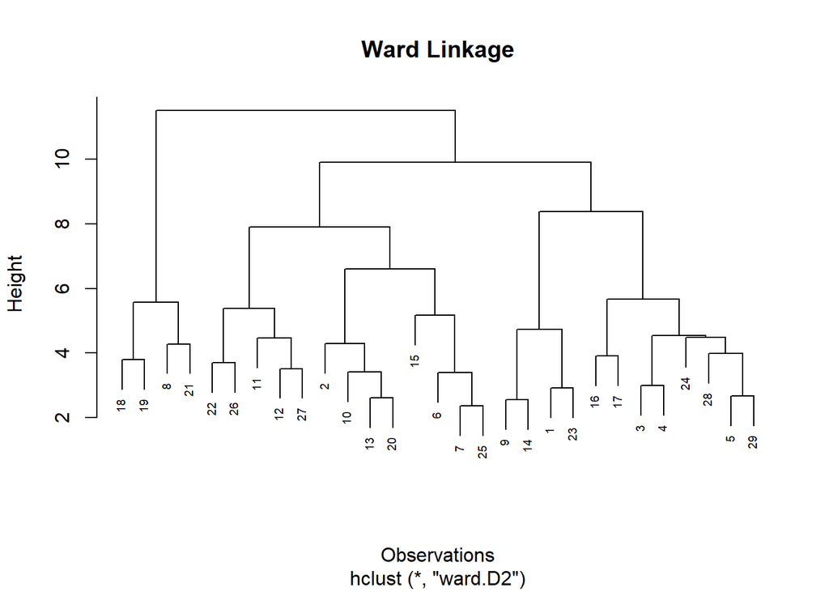

```r
# Create hierarchical clustering model using ward linkage
fit.w <- hclust(d,method="ward.D2")
plot(fit.w, main = "Ward Linkage", xlab = "Observations", ylab = "Height", cex = .6)
```

The model below shows that Iowa, Indiana, and UConn (2) are the most similar to team 25 with a couple more teams included in the group that is the most dissimilar, such as Notre Dame (13) and Tenessee (20). This model performs worse than the other two models but still captures the relationships decently well.

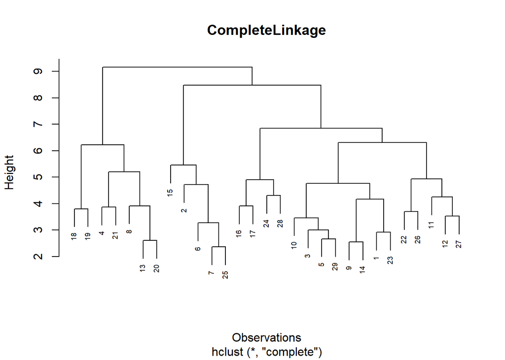

```r
# Create hierarchical clustering model using complete linkage
fit.c <- hclust(d,method="complete")
plot(fit.c, main = "CompleteLinkage", xlab = "Observations", ylab = "Height", cex = .6)
```

```r
# Check fit of hierarchical clustering models
(d.coph <- cophenetic(fit.a)) # average linkage
```

[output not shown]

[output cut: 61 more lines]

```
## 15
## 16
## 17
## 18
## 19
## 20
## 21
## 22
## 23
## 24
## 25
## 26 5.167368
## 27 5.167368 4.866953
## 28 5.422007 5.422007 5.422007
## 29 5.167368 4.866953 4.133844 5.422007
```

```r
cor(d, d.coph) # 0.6137799
```

```
## [1] 0.6137799
```

```r
(d.coph <- cophenetic(fit.w)) # ward linkage
```

[output not shown]

[output cut: 61 more lines]

```
## 15
## 16
## 17
## 18
## 19
## 20
## 21
## 22
## 23  9.901271
## 24  9.901271  8.378104
## 25  7.898793  9.901271  9.901271
## 26  3.703391  9.901271  9.901271  7.898793
## 27  5.375398  9.901271  9.901271  7.898793  5.375398
## 28  9.901271  8.378104  4.491423  9.901271  9.901271  9.901271
## 29  9.901271  8.378104  4.491423  9.901271  9.901271  9.901271  3.982356
```

```r
cor(d, d.coph) # 0.535239
```

```
## [1] 0.535239
```

```r
(d.coph <- cophenetic(fit.c)) # complete linkage
```

[output not shown]

[output cut: 61 more lines]

```
## 15
## 16
## 17
## 18
## 19
## 20
## 21
## 22
## 23
## 24
## 25
## 26 8.470987
## 27 8.470987 4.939191
## 28 8.470987 6.842537 6.842537
## 29 8.470987 6.303851 6.303851 6.842537
```

```r
cor(d, d.coph) # 0.4864656
```

```
## [1] 0.4864656
```